# Coursera Reproduciable Research Project 1

## Q5. Plot and compare the average number of steps taken per 5-minute interval across weekdays and weekends

Create a new variable with two levels, weekday and weekend based on the day of the week using the dataset with filled-in missing values

```r
activityimputed$day <- ifelse(weekdays(as.Date(activityimputed$date)) %in% c("Saturday","Sunday"), "weekend", "weekday")
```

Calculate the average number of steps taken, for weekdays

```r
library(dplyr)
stepsall <-  activityimputed[, c('interval','day','steps')]

stepsgroup <-stepsall %>%  filter(day == 'weekday')  %>%
              group_by(day, interval) %>%                            # multiple group columns
            summarise(steps = mean(steps))
stepsweekday <-   tapply(stepsgroup$steps, stepsgroup$interval, mean, na.rm = TRUE)
```

Time series plot of the average number of steps taken for weekdays

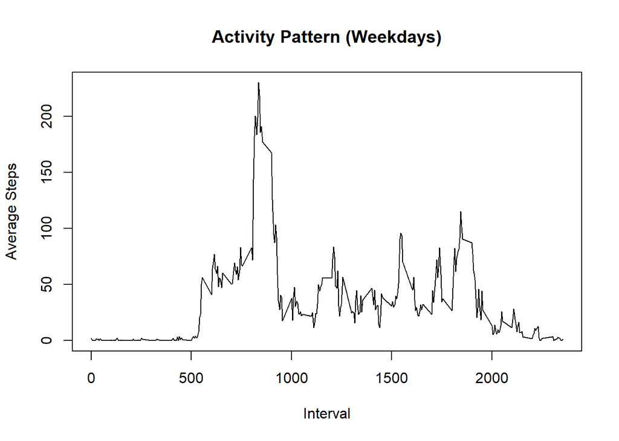

```r
plot(as.numeric(names(stepsweekday)),
     stepsweekday,
     xlab = "Interval",
     ylab = "Average Steps",
     main = "Activity Pattern (Weekdays)",
     type = "l")
```

```r
stepsgroup <-stepsall %>%  filter(day == 'weekend')  %>%
              group_by(day, interval) %>%                            # multiple group columns
            summarise(steps = mean(steps))
stepsweekend <-   tapply(stepsgroup$steps, stepsgroup$interval, mean, na.rm = TRUE)
```

Time series plot of the average number of steps taken for weekends

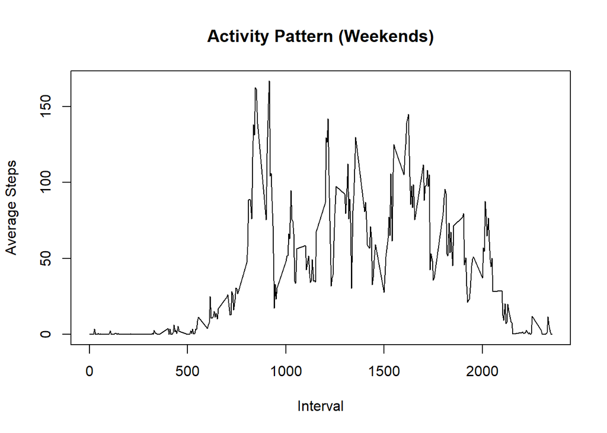

```r
plot(as.numeric(names(stepsweekend )),
     stepsweekend,
     xlab = "Interval",
     ylab = "Average Steps",
     main = "Activity Pattern (Weekends)",
     type = "l")
```

### Are there differences in activity patterns between weekdays and weekends?

Weekday activities are done less frequently than weekends.